# Clonalscope (scRNA-seq)

Chi-Yun Wu, Zhang Lab, University of Pennsylvania

## Description

For scRNA-seq data, Clonalscope enables subclone detection and malignant cell labeling.

For more information about the method, please check out the [github](https://github.com/seasoncloud/Clonalscope) and the manuscript.

## Prepare input files

The following are the input files for different steps.

1. A feature-barcode (sparse) UMI matrix. [EXAMPLE](https://github.com/seasoncloud/Alleloscope/blob/main/data-raw/SNU601/scDNA/alt_all_sub.mtx)
- The matrix is the standard output of the Cell Ranger software.
- Each element is the number of UMIs associated with a feature (row) and a barcode (column).
2. A tsv file for all cell barcodes. [EXAMPLE](https://github.com/seasoncloud/Alleloscope/blob/main/data-raw/SNU601/scDNA/barcodes_sub.tsv)
- The “barcodes.tsv” file is the standard output of the Cell Ranger software.
- Each row is a barcode indicating cell identity.
3. A tsv file for feature information. [EXAMPLE](https://github.com/seasoncloud/Alleloscope/blob/main/data-raw/SNU601/scDNA/barcodes_sub.tsv)
- The “features.tsv” file is the standard output of the Cell Ranger software.
- Each row is a gene.The first two columns need to be gene ID and gene name.
4. A matrix for cell type annotation. [EXAMPLE](https://github.com/seasoncloud/Alleloscope/blob/main/data-raw/SNU601/scDNA/barcodes_sub.tsv)
- Each row is a cell. The first and second columns are “cell barcodes” and “annotated cell types”.
- This matrix is used to specify the cells to use as the baseline for coverage normalization. Please specify the set of cells to be used as the baseline as “normal”.
5. Read count matrices from matched tumor and normal WGS/WES data. (Optional) [EXAMPLE](https://github.com/seasoncloud/Alleloscope/blob/main/data-raw/SNU601/scDNA/tumor_sub.txt)
- Each row is a bin. The values in the matrices represent total read counts for each bin.
- The matrix has four columns: col1: chr1 to 22; col2: start position; col3: end position; col4 summed read counts in the bins
- Without paired normal sample, other normal samples aligned to the same reference genome (eg. GRCh38) also work if with matched bins.
- Without matched tumor and normal WGS/WES data, chromosome arms can be used as the segments.

## Tutorial for scRNA-seq data

- Here is an example application to the P5931 scRNA-seq dataset from Sathe et al., 2020.

#### Step0. Load the input files

- In R, set up the environment and read common files

```
library(Clonalscope) # load the library
setwd("~/Clonalscope/") # set path to the github folder

dir_path <- "./samples/P5931/scRNA/output/"; dir.create(dir_path) # set up output directory

# Size of each chromosome (hg19 and GRCh38 are provided.)
size=read.table("data-raw/sizes.cellranger-GRCh38-1.0.0.txt", stringsAsFactors = F)

# List of cyclegenes retrieved from the "CopyKAT"package (https://github.com/navinlabcode/copykat)
cyclegenes=readRDS("data-raw/cyclegenes.rds")

# bed file indicating gene positions (hg19 and GRCh38 are provided.)
bed=read.table("data-raw/hg38.genes.bed", sep='\t', header = T)
```

- Read example files

```
# files for scRNA-seq data
mtx=readMM("data-raw/P5931/scRNA/filtered_feature_bc_matrix/matrix.mtx.gz")
barcodes=read.table("data-raw/P5931/scRNA/filtered_feature_bc_matrix/barcodes.tsv.gz", stringsAsFactors = F, sep='\t', header=F)
features=read.table("data-raw/P5931/scRNA/filtered_feature_bc_matrix/features.tsv.gz", stringsAsFactors = F, sep='\t', header=F)
celltype0=readRDS("data-raw/P5931/scRNA/celltype_all.rds")

# files for matched WGS/WES data
WGSt=readRDS(paste0("data-raw/P5931/WGS/raw_counts.rds"))
WGSn=readRDS(paste0("data-raw/P5931/WGS/ref_counts.rds"))
```

#### Step1. Segment the genome using matched WGS/WES data (Optional)

- Chromosome arms can be used as the segments without mathced WGS/WES data.
- First, create an object for segmentation.

```
Obj_filtered=Createobj_bulk(raw_counts=WGSt, # from matched DNA sequencing (bulk/single)
                            ref_counts=WGSn, # from matched DNA sequencing (bulk/single)
                            samplename= "P5931",
                            genome_assembly="GRCh38", dir_path=dir_path, size=size, assay='WGS')
```

- Segment the genome on matched WGS data.

```
Obj_filtered=Segmentation_bulk(Obj_filtered=Obj_filtered,
                               plot_seg = TRUE, hmm_states = c(0.8, 1.1, 1.2))
```

#### Step2. Subclone detection in scRNA-seq data

- Assign cells to be used as baseline for coverage normalization as “normal”

```
celltype=celltype0
celltype[which(!grepl('Epithelial', celltype[,2])),2]='normal'
```

- Select barcodes for clustering only on epithelial cells

```
clustering_barcodes=celltype[which(grepl("Epithelial",celltype[,2])),1]
```

- Filter input files

```
Input_filtered=FilterFeatures(mtx=mtx, barcodes=barcodes, features=features, cyclegenes=cyclegenes)

# Remove raw inputs
rm(mtx); rm(barcodes); rm(features)
```

- Subclone detection in scRNA-seq data

```
set.seed(2022)
Cov_obj=RunCovCluster(mtx=Input_filtered$mtx, barcodes=Input_filtered$barcodes,
                      features=Input_filtered$features, bed=bed,
                      celltype0=celltype, var_pt=0.99, var_pt_ctrl=0.99, include='all',
                      alpha_source='all', ctrl_region=NULL,
                      seg_table_filtered=Obj_filtered$seg_table, size=size,
                      dir_path=dir_path, breaks=50, prep_mode = 'intersect', est_cap = 2,
                      clust_mode='cna_only',clustering_barcodes=clustering_barcodes)
```

#### Step3. Visualization

- Extract values from the object.

[output not shown]

- Visualize the subclones/clusters in the heatmap.

```
PlotClusters(df = Cov_obj$result_final$df_obj$df, celltype = celltype0, Assign_obj =result, mode = "genome",  fontsize = 7, lab_mode='annot')
```

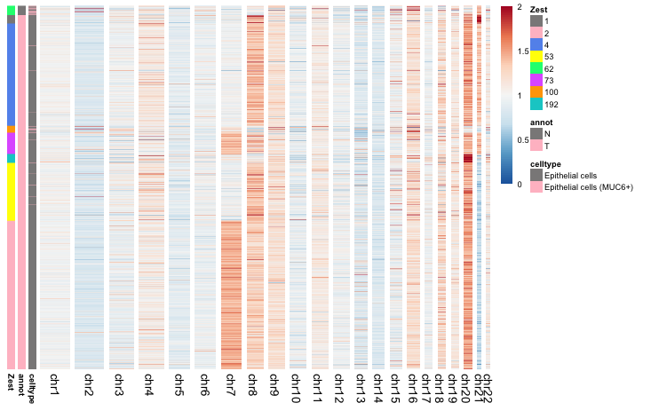

- Visuzlize the subclones/clusters in the UMAP.

```
* Plot the UMAP and save the coordinates
set.seed(2022)
emb=PlotUMAP(df = Cov_obj$result_final$df_obj$df, celltype = celltype0, Assign_obj =result, mode = "Zest")
```

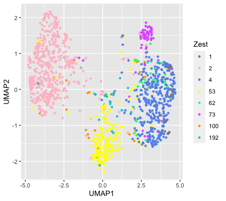

## Citation

Wu, C.-Y. et al. Integrative single-cell analysis of allele-specific copy number alterations and chromatin accessibility in cancer. Nature Biotechnology (2021): https://doi.org/10.1038/s41587-021-00911-w

[Back to the main page](https://github.com/seasoncloud/Alleloscope)